# Transit Projects

### Data Visualization Exercise

**Data source**: [Transit Costs Project](https://transitcosts.com/)

**Dataset features** (from [TidyTuesday](https://github.com/rfordatascience/tidytuesday/blob/master/data/2021/2021-01-05/readme.md)):

- e: ID
- country: Country Code - can be joined against countrycode via ecb or iso2c
- city: City where transit tunnel is being created
- line: Line name or path
- start_year: Year started
- end_year: Year ended (predicted or actual)
- rr: I think this is Railroad (0 or 1), where 1 == Railroad?
- length: Length of proposed line in km
- tunnel_per: Percent of line length completed
- tunnel: Tunnel length of line completed in km (can take this divided by length to get tunnel_per)
- stations: Number of stations where passengers can board/leave
- source1: Where was data sourced
- cost: Cost in millions of local currency
- currency: Currency type
- year: Midpoint year of construction
- ppp_rate: purchasing power parity (PPP), based on the midpoint of construction
- real_cost: Real cost in Millions of USD
- cost_km_millions: Cost/km in millions of USD
- source2: Where was data sourced for cost
- reference: reference

### Load packages

```r
library(tidyverse)
library(janitor)
library(Hmisc)
library(ggsci)
library(wesanderson)
library(patchwork)
library(countrycode)
```

### Import data

```r
transit_cost <- readr::read_csv('https://raw.githubusercontent.com/rfordatascience/tidytuesday/master/data/2021/2021-01-05/transit_cost.csv')
dim(transit_cost)
```

```
[1] 544  20
```

### Data preparation

```r
# drop obs with no ID
transit_cost = transit_cost %>% filter(!is.na(e))
dim(transit_cost)
```

```
[1] 537  20
```

```r
# parse numeric variables interpreted as character
transit_cost <- transit_cost %>%
  mutate(tunnel_per = replace_na(parse_number(tunnel_per), 0),
         real_cost = parse_number(real_cost),
         across(start_year:end_year, as.numeric))
```

[output not shown]

```r
# number of countries
length(unique(transit_cost$country))
```

```
[1] 56
```

```r
# get country names
transit_cost$country2= countrycode(transit_cost$country,"iso2c", "country.name")
```

```
Some values were not matched unambiguously: UK
```

```r
# get continent
transit_cost$continent <- countrycode(sourcevar = transit_cost[["country"]],
                            origin = "iso2c",
                            destination = "continent")
```

```
Some values were not matched unambiguously: UK
```

```r
# change NA to United Kingdom
transit_cost = transit_cost %>% mutate(country2=ifelse(is.na(country2),"United Kingdom",country2)) %>% mutate(continent=ifelse(is.na(continent),"Europe",continent))
```

```r
# summary of project count by continent
transit_cost %>% group_by(continent) %>% tally() %>% mutate(proportion=round(n/sum(n),3))
```

| continent | n | proportion |
| --- | --- | --- |
| Africa | 7 | 0.013 |
| Americas | 36 | 0.067 |
| Asia | 387 | 0.721 |
| Europe | 102 | 0.190 |
| Oceania | 5 | 0.009 |

```r
# cost/station
transit_cost$cost_station = transit_cost$real_cost/transit_cost$stations
# drop country with Nan in avg_cost_station
transit_cost = transit_cost %>% filter(country2!="Qatar")

# railroad and non-railroad
Hmisc::describe(as.factor(transit_cost$rr))
```

```
as.factor(transit_cost$rr)
       n  missing distinct
     535        1        2

Value          0     1
Frequency    501    34
Proportion 0.936 0.064
```

```r
# railroad df
railroad = transit_cost %>% filter(rr=="1")
# non-railroad df
not_railroad = transit_cost %>% filter(rr=="0")
```

### Cost of non-railroad transit projects by continent

```r
p1 = not_railroad %>% ggplot(aes(x=continent, y=real_cost, color=continent)) + geom_boxplot(outlier.color="white",alpha=0) + scale_color_uchicago() + theme(legend.position="none") + geom_jitter(shape=16, position=position_jitter(0.2), alpha=0.7) + labs(subtitle="Real Cost", y="Real cost in USD Millions", x="")
p2 = not_railroad %>% ggplot(aes(x=continent, y=cost_km_millions, color=continent)) + geom_boxplot(outlier.color="white",alpha=0) + scale_color_uchicago() + theme(legend.position="none") + geom_jitter(shape=16, position=position_jitter(0.2), alpha=0.7) + labs(subtitle="Cost per Kilometer", y="Cost/km in USD millions", x="")
p3 = not_railroad %>% ggplot(aes(x=continent, y=cost_station, color=continent)) + geom_boxplot(outlier.color="white",alpha=0) + scale_color_uchicago() + theme(legend.position="none") + geom_jitter(shape=16, position=position_jitter(0.2), alpha=0.7) + labs(subtitle="Cost per Station",y="Cost/station in USD millions", x="")
```

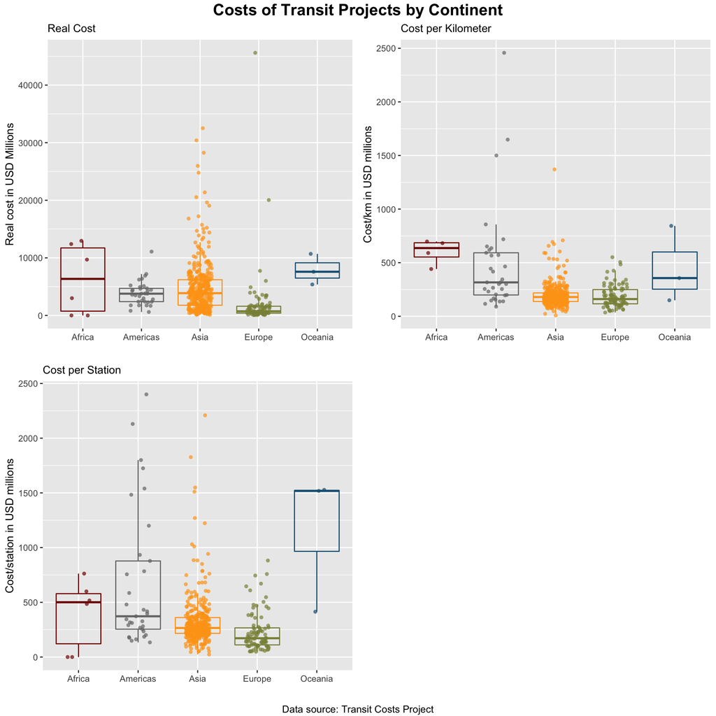

```r
library(ggpubr)
figure1 = ggarrange(p1, p2, p3, ncol=2, nrow=2)
annotate_figure(figure1, top= text_grob("Costs of Transit Projects by Continent", color="black",face="bold",size=16),
  bottom=text_grob("Data source: Transit Costs Project", size=10))
```

### Countries with highest non-railroad project costs

```r
# non_railroad project costs
nr_pc = not_railroad %>% group_by(country2) %>% summarise(count_project = n(), avg_real_cost = mean(real_cost,na.rm=TRUE), avg_cost_km = mean(cost_km_millions,na.rm=TRUE), avg_cost_station=mean(cost_station, na.rm=TRUE)) %>% as.data.frame()
# append count to country name
nr_pc$country2_p = paste0(nr_pc$country2,"(",nr_pc$count_project,")")
```

```r
# individual plots
w1 = nr_pc %>% arrange(desc(count_project)) %>% head(10) %>% ggplot(aes(x=reorder(country2_p,count_project), y=count_project)) + geom_col(fill="#606c38", width=0.7) + coord_flip() + labs(y="Project count", x="Country(project count)", title= "Top 10 by project count") + theme_minimal()

w2 = nr_pc %>% arrange(desc(avg_real_cost)) %>% head(10) %>% ggplot(aes(x=reorder(country2_p,avg_real_cost), y=avg_real_cost)) + geom_col(fill="#283618", width=0.7) + coord_flip() + labs(y="Avg. real cost (in USD millions)", x="", title= "Top 10 by average real cost") + theme_minimal()

w3 = nr_pc %>% arrange(desc(avg_cost_km)) %>% head(10) %>% ggplot(aes(x=reorder(country2_p,avg_cost_km), y=avg_cost_km)) + geom_col(fill="#dda15e", width=0.7) + coord_flip() + labs(y="Avg. cost/km (in USD millions)", x="Country(project count)", title= "Top 10 by average cost/km") + theme_minimal()

w4 = nr_pc %>% arrange(desc(avg_cost_station)) %>% head(10) %>% ggplot(aes(x=reorder(country2_p,avg_cost_station), y=avg_cost_station)) + geom_col(fill="#bc6c25", width=0.7) + coord_flip() + labs(y="Avg. cost/station (in USD millions)", x="", title= "Top 10 by average cost/station") + theme_minimal()
```

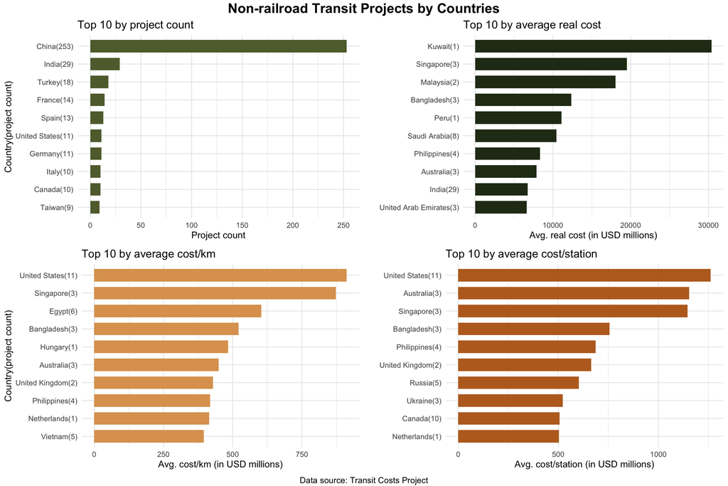

```r
# combined plot
figure3= ggarrange(w1,w2,w3,w4,ncol=2, nrow=2)
annotate_figure(figure3, top= text_grob("Non-railroad Transit Projects by Countries", color="black",face="bold",size=16),
  bottom=text_grob("Data source: Transit Costs Project", size=10))
```

### European cities with highest non-railroad project costs (excl. Russia)

```r
# get averages
eu1= not_railroad %>% filter(continent=="Europe") %>% filter(country2!="Russia") %>% group_by(country, city) %>% summarise(projects_n=n(), avg_real_cost = mean(real_cost,na.rm=TRUE), avg_cost_km = mean(cost_km_millions,na.rm=TRUE), avg_cost_station=mean(cost_station, na.rm=TRUE))
# append country to city
eu1$city_country = paste0(eu1$city,",",eu1$country)

# individual plots
e1 = eu1 %>% arrange(desc(projects_n)) %>% head(10) %>% ggplot(aes(x=reorder(city_country,projects_n), y=projects_n)) + geom_col(fill="#335c67", width=0.7) + coord_flip() + labs(y="Project count", x="City,Country", title= "Top 10 by project count") + theme_minimal() + scale_y_continuous(limits=c(0,11))

e2 = eu1 %>% arrange(desc(avg_real_cost)) %>% head(10) %>% ggplot(aes(x=reorder(city_country,avg_real_cost), y=avg_real_cost)) + geom_col(fill="#e09f3e", width=0.7) + coord_flip() + labs(y="Avg. real cost (in USD millions)", x="", title= "Top 10 by average real cost") + theme_minimal() + scale_y_continuous(limits=c(0,5500))

e3 = eu1 %>% arrange(desc(avg_cost_km)) %>% head(10) %>% ggplot(aes(x=reorder(city_country,avg_cost_km), y=avg_cost_km)) + geom_col(fill="#9e2a2b", width=0.7) + coord_flip() + labs(y="Avg. cost/km (in USD millions)", x="City,Country", title= "Top 10 by average cost/km") + theme_minimal() + scale_y_continuous(limits=c(0,550))

e4 =eu1 %>% arrange(desc(avg_cost_station)) %>% head(10) %>% ggplot(aes(x=reorder(city_country,avg_cost_station), y=avg_cost_station)) + geom_col(fill="#540b0e", width=0.7) + coord_flip() + labs(y="Avg. cost/station (in USD millions)", x="", title= "Top 10 by average cost/station") + theme_minimal() + scale_y_continuous(limits=c(0,850))
```

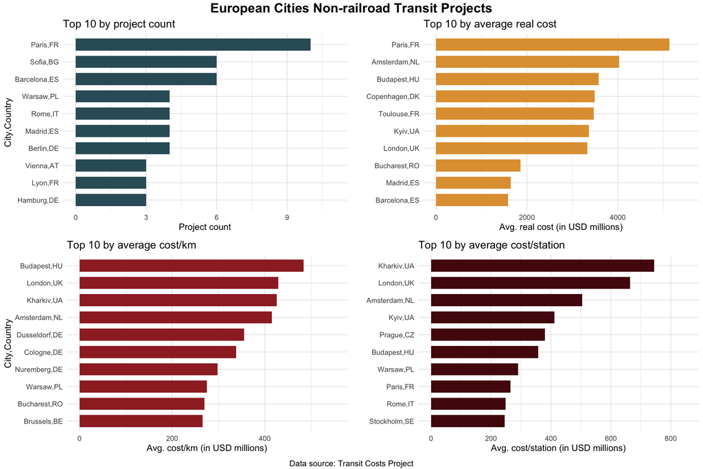

```r
# combined plot
figure2= ggarrange(e1,e2,e3,e4,nrow=2,ncol=2)
annotate_figure(figure2, top= text_grob("European Cities Non-railroad Transit Projects", color="black",face="bold",size=16),
  bottom=text_grob("Data source: Transit Costs Project", size=10))
```

### Length/stations

- get approximate distance between stations using length(km) divided by stations

```r
# length_stations
transit_cost = transit_cost %>% mutate(length_stations = length/stations)
transit_cost$length_stations[sapply(transit_cost$length_stations, is.infinite)] <- NA
summary(transit_cost$length_stations)
```

```
   Min. 1st Qu.  Median    Mean 3rd Qu.    Max.    NA's
 0.5667  1.1424  1.3833  1.6889  1.8713 14.6667      10
```

#### length/stations of railroad and non-railroad projects

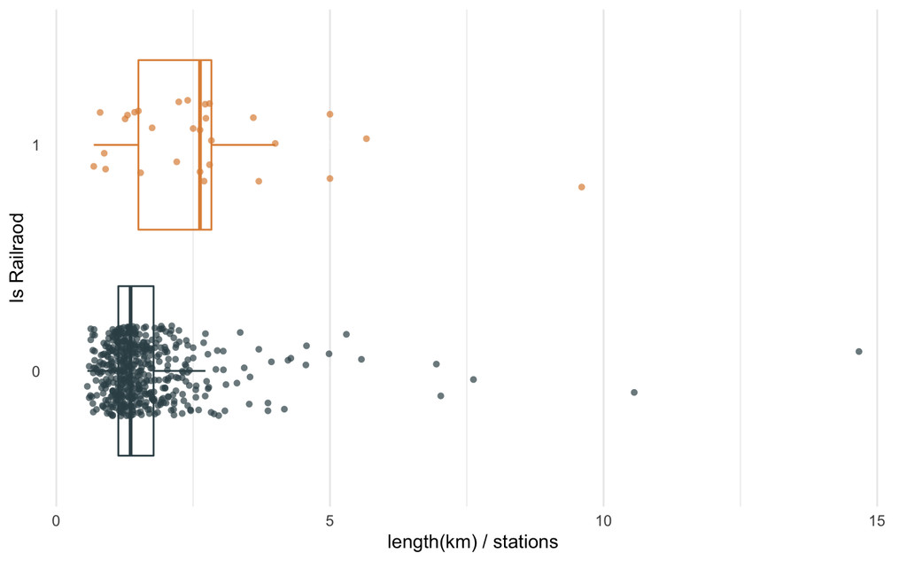

```r
#plot
transit_cost %>% filter(!is.na(rr)) %>% ggplot(aes(x=factor(rr), y=length_stations, color=factor(rr))) + geom_boxplot(outlier.color="white",alpha=0.1) + geom_jitter(shape=16, position=position_jitter(0.2), alpha=0.7) + scale_color_jama() + coord_flip() + theme_minimal() + theme(legend.position="none", panel.grid.minor.y=element_blank(),panel.grid.major.y=element_blank()) + labs(y="length(km) / stations", x="Is Railraod")
```

#### length/stations and city (non-railroad projects)

```r
lsc = transit_cost %>% filter(rr==0) %>% group_by(city) %>% summarise(avg_length_stations = mean(length_stations)) %>% filter(!is.na(avg_length_stations))
summary(lsc$avg_length_stations)
```

```
   Min. 1st Qu.  Median    Mean 3rd Qu.    Max.
 0.5667  1.0543  1.3056  1.4072  1.6467  3.5275
```

```r
# cities with lowest average length/stations
lsc %>% arrange(avg_length_stations) %>% head(5)
```

| city | avg_length_stations |
| --- | --- |
| Dusseldorf | 0.5666667 |
| Nuremberg | 0.6000000 |
| Brussels | 0.6285714 |
| Tel Aviv | 0.6642315 |
| Malaga | 0.6647059 |

```r
# cities with highest average length/stations
lsc %>% arrange(desc(avg_length_stations)) %>% head(5)
```

| city | avg_length_stations |
| --- | --- |
| Sydney | 3.527473 |
| Moscow | 3.009140 |
| Guangzhou | 2.664853 |
| Riyadh | 2.594081 |
| Dongguan | 2.569984 |

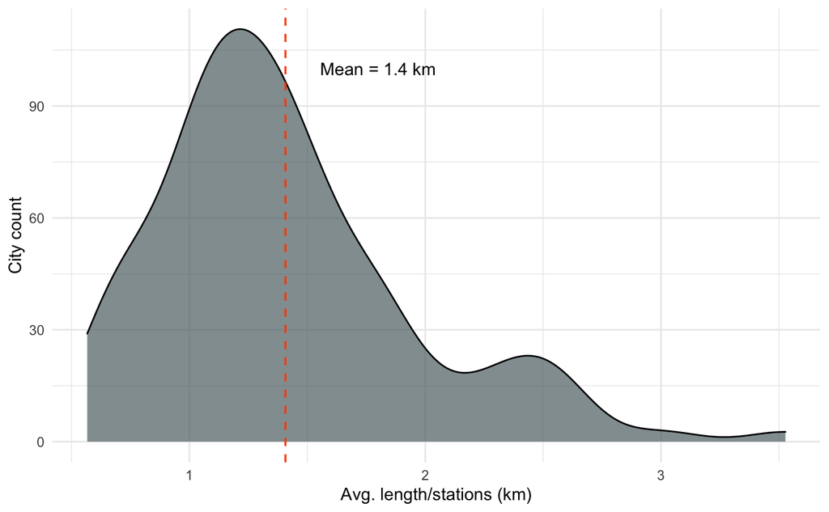

```r
# density plot
ggplot(lsc, aes(x = avg_length_stations)) + geom_density(aes(y = ..count..), fill = "#5c6d70",alpha=0.7) +
  geom_vline(aes(xintercept = mean(avg_length_stations)),
             linetype = "dashed", size = 0.6,
             color = "#FC4E07") +
  annotate("text", x = 1.8, y = 100, label = "Mean = 1.4 km") +
  theme_minimal() +
  labs(x="Avg. length/stations (km)",y="City count")
```

### Length and real cost (non-railroad projects)

- inspired by [@MartinPons](https://twitter.com/MartinPonsM/status/1347079193998327810)

```r
outliers_length = boxplot(not_railroad$length, plot=FALSE)$out # get outliers in length
min(outliers_length) # get minimum
```

```
[1] 66.7
```

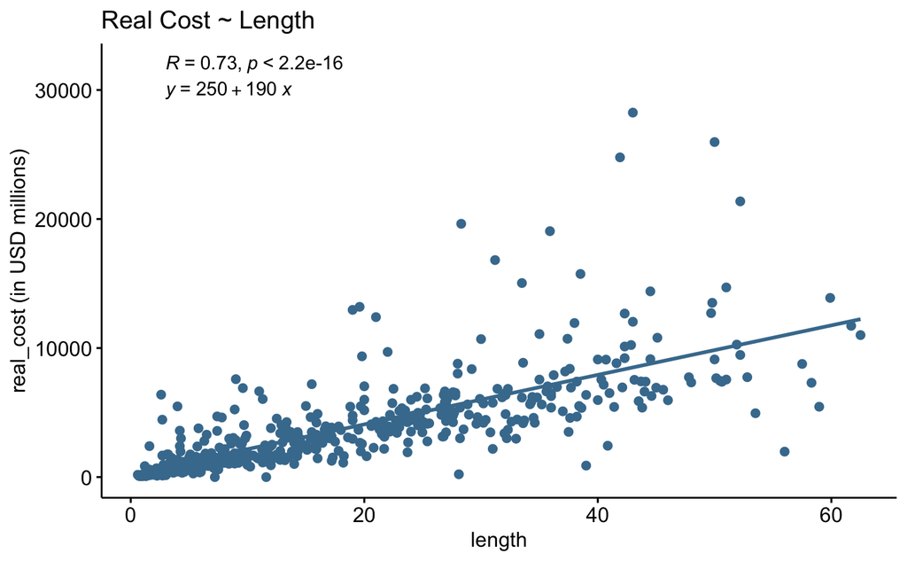

```r
# scatter plot with correlation coefficient and regression line
nrr1= not_railroad %>% filter(length <66.7) # drop outliers
ggscatter(nrr1, x = "length", y = "real_cost", add = "reg.line", color="#457b9d") +
  stat_cor(label.x = 3, label.y = 32000) +
  stat_regline_equation(label.x = 3, label.y = 30000) + labs(y="real_cost (in USD millions)", title="Real Cost ~ Length")
```

### Stations and real cost (non-railroad projects)

```r
outliers_stations = boxplot(not_railroad$stations, plot=FALSE)$out # outliers in stations
min(outliers_stations) # get minimum
```

```
[1] 43
```

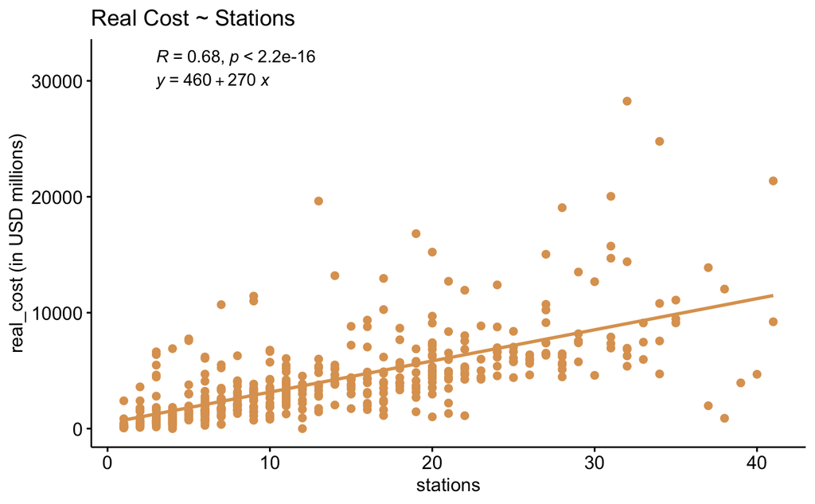

```r
nrr2= not_railroad %>% filter(stations < 43) # drop outliers
ggscatter(nrr2, x = "stations", y = "real_cost", add = "reg.line", color="#dda15e") +
  stat_cor(label.x = 3, label.y = 32000) +
  stat_regline_equation(label.x = 3, label.y = 30000) + labs(y="real_cost (in USD millions)", title="Real Cost ~ Stations")
```

### Years to complete and real cost (non-railroad projects)

```r
not_railroad = not_railroad %>% mutate(years_to_complete = end_year - start_year)
summary(not_railroad$years_to_complete)
```

```
   Min. 1st Qu.  Median    Mean 3rd Qu.    Max.    NA's
  1.000   4.000   5.000   5.558   7.000  23.000      73
```

```r
outliers_years = boxplot(not_railroad$years_to_complete, plot=FALSE)$out
min(outliers_years)
```

```
[1] 12
```

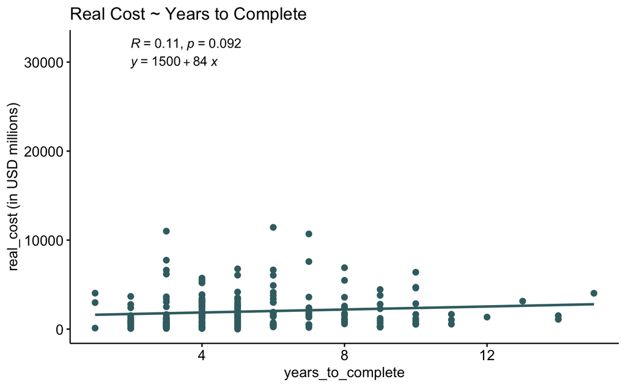

```r
nrr3= not_railroad %>% filter(stations < 12) # drop outliers
ggscatter(nrr3, x = "years_to_complete", y = "real_cost", add = "reg.line", color="#3c6e71") +
  stat_cor(label.x = 2, label.y = 32000) +
  stat_regline_equation(label.x = 2, label.y = 30000) + labs(y="real_cost (in USD millions)", title="Real Cost ~ Years to Complete")
```